# LBB6

Ambiya Sang Aji

May 24, 2019

# Overview

Dalam report ini, akan dilakukan prediksi dengan menggunakan dataset loan default, performansi akan diukur menggunakan accuracy, dikarenakan dalam kasus ini dibutuhkan prediksi akurat untuk kedua class, karena ada faktor risk loss jika gagal memprediksi loan default, dan jika terlalu renggang untuk memprediksi loan default, ada resiko hasil pencadangan yang harus dilakukan oleh bank akan semakin tinggi, dikarenakan setiap loan default, sebuah bank harus mencadangkan nilai untuk menutupi risk dari loss yang akan dialami. sehingga dibutuhkan model yang mampu memprediksi secara akurat kedua class.

Akan dilakukan komparaasi antara 3 algoritma, yaitu naive bayes, dacision tree dan random forest dan dicoba interpretasikan dari ke 3 model tersebut performancenya.

# Read and Analyze Data

Tidak ada dataset N/A, akan dilakukan pengecekan top 6 data

```r
head(loan)
```

|  | checking_balance | months_loan_duration | credit_history | purpose | amount | savings_balance | employment_duration | percent_of_income | years_at_residence | age | other_credit | housing | existing_loans_count | job | dependents | phone | default |
| --- | --- | --- | --- | --- | --- | --- | --- | --- | --- | --- | --- | --- | --- | --- | --- | --- | --- |
| 1 | < 0 DM | 6 | critical | furniture/appliances | 1169 | unknown | > 7 years | 4 | 4 | 67 | none | own | 2 | skilled | 1 | yes | no |
| 2 | 1 - 200 DM | 48 | good | furniture/appliances | 5951 | < 100 DM | 1 - 4 years | 2 | 2 | 22 | none | own | 1 | skilled | 1 | no | yes |
| 3 | unknown | 12 | critical | education | 2096 | < 100 DM | 4 - 7 years | 2 | 3 | 49 | none | own | 1 | unskilled | 2 | no | no |
| 4 | < 0 DM | 42 | good | furniture/appliances | 7882 | < 100 DM | 4 - 7 years | 2 | 4 | 45 | none | other | 1 | skilled | 2 | no | no |
| 5 | < 0 DM | 24 | poor | car | 4870 | < 100 DM | 1 - 4 years | 3 | 4 | 53 | none | other | 2 | skilled | 2 | no | yes |
| 6 | unknown | 36 | good | education | 9055 | unknown | 1 - 4 years | 2 | 4 | 35 | none | other | 1 | unskilled | 2 | yes | no |

Walaupun tidak ada data N/A, namun ada data unknown di dalam variable saving balance dan checking balance, tidak akan dilakukan processing terhadap variable tersebut, karena varriable tersebut dapat dikatakan masih termasuk sebuah factor.

Akan dilakukan splitting data terlebih dahulu untuk dijadikan train dan test dataset

```r
set.seed(99)
split <- initial_split(loan, prop = 0.8, strata = "default")
prop.table(table(training(split)$default))
```

```
#>
#>        no       yes
#> 0.6995012 0.3004988
```

```r
prop.table(table(testing(split)$default))
```

```
#>
#>        no       yes
#> 0.7020202 0.2979798
```

Target klasifikasi di dataset telah terbagi secara rata, selanjutnya akan dilakukan preprocessing lebih lanjut

Tanpa Melakukan downsample :

```r
rec <- recipe(default ~ ., data =training(split)) %>%
  step_nzv(all_predictors()) %>%
  step_string2factor(all_nominal(),-default) %>%
  step_string2factor(default,levels = c("yes","no")) %>%
  step_center(all_numeric()) %>%
  step_scale(all_numeric()) %>%
  prep(strings_as_factors = FALSE)

X <- juice(rec)
Xtr <- bake(rec,testing(split))
```

# Modelling - Naive Bayes

Melakukan 5-fold cross validation dengan 3 kali pengulangan untuk melihat average dari performance model, sekaligus melakukan pengecekan beberapa parameter

```r
search_grid <- expand.grid(
  usekernel = c(TRUE, FALSE),
  fL = 0:5,
  adjust = seq(0, 5, by = 1)
)
set.seed(99)
nvb <- train(x = X[,1:16],
               y = X$default,
               method = 'nb',
               metric='Accuracy',
               trControl = trainControl(method = 'repeatedcv', # repeated cross validation
                                        number = 5, # nr of partitions
                                        repeats = 3, # nr of repeats=,
                                        classProbs = T),
              tuneGrid = search_grid)
```

```r
nvb
```

```
#> Naive Bayes
#>
#> 802 samples
#>  16 predictor
#>   2 classes: 'no', 'yes'
#>
#> No pre-processing
#> Resampling: Cross-Validated (5 fold, repeated 3 times)
#> Summary of sample sizes: 642, 640, 642, 642, 642, 642, ...
#> Resampling results across tuning parameters:
#>
#>   usekernel  fL  adjust  Accuracy   Kappa
#>   FALSE      0   0       0.7364661  0.3262612
#>   FALSE      0   1       0.7364661  0.3262612
#>   FALSE      0   2       0.7364661  0.3262612
#>   FALSE      0   3       0.7364661  0.3262612
#>   FALSE      0   4       0.7364661  0.3262612
#>   FALSE      0   5       0.7364661  0.3262612
#>   FALSE      1   0       0.7360469  0.3322551
#>   FALSE      1   1       0.7360469  0.3322551
#>   FALSE      1   2       0.7360469  0.3322551
#>   FALSE      1   3       0.7360469  0.3322551
#>   FALSE      1   4       0.7360469  0.3322551
#>   FALSE      1   5       0.7360469  0.3322551
#>   FALSE      2   0       0.7331405  0.3341412
#>   FALSE      2   1       0.7331405  0.3341412
#>   FALSE      2   2       0.7331405  0.3341412
#>   FALSE      2   3       0.7331405  0.3341412
#>   FALSE      2   4       0.7331405  0.3341412
#>   FALSE      2   5       0.7331405  0.3341412
#>   FALSE      3   0       0.7302368  0.3363943
#>   FALSE      3   1       0.7302368  0.3363943
#>   FALSE      3   2       0.7302368  0.3363943
#>   FALSE      3   3       0.7302368  0.3363943
#>   FALSE      3   4       0.7302368  0.3363943
#>   FALSE      3   5       0.7302368  0.3363943
#>   FALSE      4   0       0.7302446  0.3450717
#>   FALSE      4   1       0.7302446  0.3450717
#>   FALSE      4   2       0.7302446  0.3450717
#>   FALSE      4   3       0.7302446  0.3450717
```

[output cut: 33 more lines]

```
#>    TRUE      4   1       0.7306766  0.2788975
#>    TRUE      4   2       0.7364738  0.2986598
#>    TRUE      4   3       0.7347865  0.2788381
#>    TRUE      4   4       0.7360236  0.2691313
#>    TRUE      4   5       0.7314558  0.2392438
#>    TRUE      5   0             NaN        NaN
#>    TRUE      5   1       0.7314997  0.2873105
#>    TRUE      5   2       0.7385623  0.3151708
#>    TRUE      5   3       0.7372813  0.2903453
#>    TRUE      5   4       0.7360262  0.2743163
#>    TRUE      5   5       0.7331122  0.2506758
#>
#> Accuracy was used to select the optimal model using the largest value.
#> The final values used for the model were fL = 5, usekernel = TRUE
#>  and adjust = 2.
```

# Testing - Naive Bayes

Akan dicoba dilakukan pengecekan terhadap confusion matrixnya

```r
Xtrlabel <- Xtr[,17]
Xtr <- Xtr[,-17]
nvbpredict <- predict(nvb$finalModel, Xtr, type="raw")
```

```r
confusionMatrix(nvbpredict$class,Xtrlabel$default,positive='no')
```

```
#> Confusion Matrix and Statistics
#>
#>           Reference
#> Prediction  no yes
#>        no  127  43
#>        yes  12  16
#>
#>                Accuracy : 0.7222
#>                  95% CI : (0.6543, 0.7834)
#>     No Information Rate : 0.702
#>     P-Value [Acc > NIR] : 0.2959
#>
#>                   Kappa : 0.2178
#>
#>  Mcnemar's Test P-Value : 5.228e-05
#>
#>             Sensitivity : 0.9137
#>             Specificity : 0.2712
#>          Pos Pred Value : 0.7471
#>          Neg Pred Value : 0.5714
#>              Prevalence : 0.7020
#>          Detection Rate : 0.6414
#>    Detection Prevalence : 0.8586
#>       Balanced Accuracy : 0.5924
#>
#>        'Positive' Class : no
#>
```

Didapatkan hasil accuracy = 72%, akan dilakukan preprosesing dengan melakukan downsampling, dan melakukan perbandingan terhadap hasilnya

# Naive Bayes - With Downsampling

Dengan Melakukan downsample :

```r
rec2 <- recipe(default ~ ., data =training(split)) %>%
  step_nzv(all_predictors()) %>%
  step_string2factor(all_nominal(),-default) %>%
  step_string2factor(default,levels = c("yes","no")) %>%
  step_downsample(default, ratio = 1/1, seed = 100) %>%
  step_center(all_numeric()) %>%
  step_scale(all_numeric()) %>%
  prep(strings_as_factors = FALSE)

X2 <- juice(rec2)
Xtr2 <- bake(rec,testing(split))
```

Melakukan 5-fold cross validation dengan 3 kali pengulangan untuk melihat average dari performance model, sekaligus melakukan pengecekan beberapa parameter

```r
search_grid <- expand.grid(
  usekernel = c(TRUE, FALSE),
  fL = 0:5,
  adjust = seq(0, 5, by = 1)
)
set.seed(99)
nvb2 <- train(x = X2[,1:16],
               y = X2$default,
               method = 'nb',
               metric='Accuracy',
               trControl = trainControl(method = 'repeatedcv', # repeated cross validation
                                        number = 5, # nr of partitions
                                        repeats = 3, # nr of repeats=,
                                        classProbs = T),
              tuneGrid = search_grid)
```

```r
nvb2
```

```
#> Naive Bayes
#>
#> 482 samples
#>  16 predictor
#>   2 classes: 'no', 'yes'
#>
#> No pre-processing
#> Resampling: Cross-Validated (5 fold, repeated 3 times)
#> Summary of sample sizes: 386, 384, 386, 386, 386, 386, ...
#> Resampling results across tuning parameters:
#>
#>   usekernel  fL  adjust  Accuracy   Kappa
#>   FALSE      0   0       0.6852688  0.3706140
#>   FALSE      0   1       0.6852688  0.3706140
#>   FALSE      0   2       0.6852688  0.3706140
#>   FALSE      0   3       0.6852688  0.3706140
#>   FALSE      0   4       0.6852688  0.3706140
#>   FALSE      0   5       0.6852688  0.3706140
#>   FALSE      1   0       0.6838801  0.3678357
#>   FALSE      1   1       0.6838801  0.3678357
#>   FALSE      1   2       0.6838801  0.3678357
#>   FALSE      1   3       0.6838801  0.3678357
#>   FALSE      1   4       0.6838801  0.3678357
#>   FALSE      1   5       0.6838801  0.3678357
#>   FALSE      2   0       0.6832210  0.3665115
#>   FALSE      2   1       0.6832210  0.3665115
#>   FALSE      2   2       0.6832210  0.3665115
#>   FALSE      2   3       0.6832210  0.3665115
#>   FALSE      2   4       0.6832210  0.3665115
#>   FALSE      2   5       0.6832210  0.3665115
#>   FALSE      3   0       0.6797631  0.3595995
#>   FALSE      3   1       0.6797631  0.3595995
#>   FALSE      3   2       0.6797631  0.3595995
#>   FALSE      3   3       0.6797631  0.3595995
#>   FALSE      3   4       0.6797631  0.3595995
#>   FALSE      3   5       0.6797631  0.3595995
#>   FALSE      4   0       0.6769995  0.3540757
#>   FALSE      4   1       0.6769995  0.3540757
#>   FALSE      4   2       0.6769995  0.3540757
#>   FALSE      4   3       0.6769995  0.3540757
```

[output cut: 33 more lines]

```
#>    TRUE      4   1       0.6887269  0.3774983
#>    TRUE      4   2       0.6894352  0.3788838
#>    TRUE      4   3       0.6804219  0.3608877
#>    TRUE      4   4       0.6735417  0.3471676
#>    TRUE      4   5       0.6673135  0.3346031
#>    TRUE      5   0             NaN        NaN
#>    TRUE      5   1       0.6838657  0.3677761
#>    TRUE      5   2       0.6873518  0.3747172
#>    TRUE      5   3       0.6818036  0.3636469
#>    TRUE      5   4       0.6721742  0.3443940
#>    TRUE      5   5       0.6672992  0.3345618
#>
#> Accuracy was used to select the optimal model using the largest value.
#> The final values used for the model were fL = 1, usekernel = TRUE
#>  and adjust = 2.
```

```r
Xtrlabel2 <- Xtr2[,17]
Xtr2 <- Xtr2[,-17]
nvbpredict2 <- predict(nvb2$finalModel, Xtr2, type="raw")
```

```r
confusionMatrix(nvbpredict2$class,Xtrlabel2$default,positive='no')
```

```
#> Confusion Matrix and Statistics
#>
#>           Reference
#> Prediction  no yes
#>        no  109  19
#>        yes  30  40
#>
#>                Accuracy : 0.7525
#>                  95% CI : (0.6864, 0.811)
#>     No Information Rate : 0.702
#>     P-Value [Acc > NIR] : 0.06811
#>
#>                   Kappa : 0.4386
#>
#>  Mcnemar's Test P-Value : 0.15313
#>
#>             Sensitivity : 0.7842
#>             Specificity : 0.6780
#>          Pos Pred Value : 0.8516
#>          Neg Pred Value : 0.5714
#>              Prevalence : 0.7020
#>          Detection Rate : 0.5505
#>    Detection Prevalence : 0.6465
#>       Balanced Accuracy : 0.7311
#>
#>        'Positive' Class : no
#>
```

Didapatkan hasil yang lebih baik dengan menggunakan metode downsampling, dikarenakan metode downsampling melakukan balancing terhadap jumlah class prediksi di training set

# Modelling - Decision Tree

Akan dilakukan modelling dengan menggunakan decision tree

```r
search_grid <- expand.grid(
mincriterion = seq(0.01, 10, by = 0.01)
)

trctrl <- trainControl(method = "repeatedcv", number = 5, repeats = 3)
set.seed(99)
dct <- train(x = X[,1:16],
                   y = X$default,
                   method = "ctree",
                   trControl=trctrl,
                   tuneGrid = search_grid)
```

```r
dct
```

```
#> Conditional Inference Tree
#>
#> 802 samples
#>  16 predictor
#>   2 classes: 'no', 'yes'
#>
#> No pre-processing
#> Resampling: Cross-Validated (5 fold, repeated 3 times)
#> Summary of sample sizes: 642, 640, 642, 642, 642, 642, ...
#> Resampling results across tuning parameters:
#>
#>   mincriterion  Accuracy   Kappa
#>    0.01         0.6945556  0.2293888
#>    0.02         0.6966337  0.2345595
#>    0.03         0.6945504  0.2321013
#>    0.04         0.6933030  0.2272591
#>    0.05         0.6920607  0.2239369
#>    0.06         0.6953915  0.2307570
#>    0.07         0.6962196  0.2277213
#>    0.08         0.6991363  0.2318830
#>    0.09         0.6991363  0.2318830
#>    0.10         0.6999645  0.2324286
#>    0.11         0.6995478  0.2323619
#>    0.12         0.7003811  0.2343224
#>    0.13         0.6999671  0.2341708
#>    0.14         0.7024465  0.2375510
#>    0.15         0.7024465  0.2353087
#>    0.16         0.7020401  0.2352847
#>    0.17         0.7024542  0.2349072
#>    0.18         0.7036965  0.2402304
#>    0.19         0.7036965  0.2402304
#>    0.20         0.7045298  0.2398235
#>    0.21         0.7028683  0.2368583
#>    0.22         0.7028683  0.2368583
#>    0.23         0.7024516  0.2366941
#>    0.24         0.7074361  0.2419492
#>    0.25         0.7090924  0.2382352
#>    0.26         0.7090924  0.2382352
#>    0.27         0.7099257  0.2348183
#>    0.28         0.7099257  0.2348183
```

[output cut: 60 more lines]

```
#>    0.89         0.7302549  0.2720993
#>    0.90         0.7306716  0.2746498
#>    0.91         0.7306716  0.2746498
#>    0.92         0.7306716  0.2746498
#>    0.93         0.7306690  0.2749138
#>    0.94         0.7310857  0.2790492
#>    0.95         0.7310857  0.2790492
#>    0.96         0.7331690  0.2831610
#>    0.97         0.7352343  0.2933420
#>    0.98         0.7344010  0.2894729
#>    0.99         0.7290230  0.2677241
#>    1.00         0.6995041  0.0000000

#> Accuracy was used to select the optimal model using the largest value.
#> The final value used for the model was mincriterion = 0.97.
```

Tree model yang dibentuk :

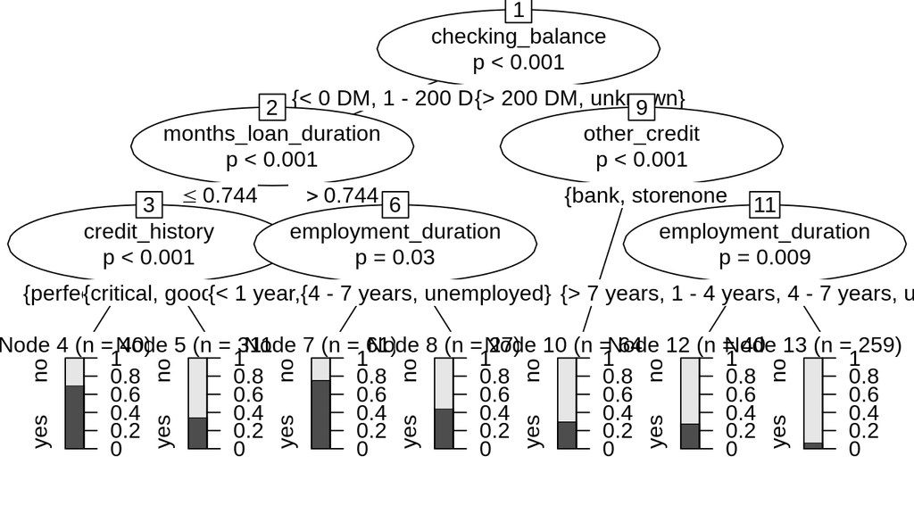

```r
plot(dct$finalModel)
```

# Testing - Decision Tree

```r
dctpredict <- predict(dct$finalModel, Xtr)
confusionMatrix(dctpredict,Xtrlabel$default,positive='no')
```

```
#> Confusion Matrix and Statistics
#>
#>           Reference
#> Prediction  no yes
#>        no  133  45
#>        yes   6  14
#>
#>                Accuracy : 0.7424
#>                  95% CI : (0.6756, 0.8018)
#>     No Information Rate : 0.702
#>     P-Value [Acc > NIR] : 0.1211
#>
#>                   Kappa : 0.2397
#>
#>  Mcnemar's Test P-Value : 1.032e-07
#>
#>             Sensitivity : 0.9568
#>             Specificity : 0.2373
#>          Pos Pred Value : 0.7472
#>          Neg Pred Value : 0.7000
#>              Prevalence : 0.7020
#>          Detection Rate : 0.6717
#>    Detection Prevalence : 0.8990
#>       Balanced Accuracy : 0.5971
#>
#>        'Positive' Class : no
#>
```

Accuracy yang dihasilkan adalah 74%, selanjutnya akan dicompare dengan menggunakan downsampling

# Decision Tree - With Downsampling

```r
search_grid <- expand.grid(
mincriterion = seq(0.01, 10, by = 0.01)
)

trctrl <- trainControl(method = "repeatedcv", number = 5, repeats = 3)
set.seed(99)
dct2 <- train(x = X2[,1:16],
                   y = X2$default,
                   method = "ctree",
                   trControl=trctrl,
                   tuneGrid = search_grid)
```

```r
dct
```

```
#> Conditional Inference Tree
#>
#> 802 samples
#>  16 predictor
#>   2 classes: 'no', 'yes'
#>
#> No pre-processing
#> Resampling: Cross-Validated (5 fold, repeated 3 times)
#> Summary of sample sizes: 642, 640, 642, 642, 642, 642, ...
#> Resampling results across tuning parameters:
#>
#>   mincriterion  Accuracy   Kappa
#>    0.01         0.6945556  0.2293888
#>    0.02         0.6966337  0.2345595
#>    0.03         0.6945504  0.2321013
#>    0.04         0.6933030  0.2272591
#>    0.05         0.6920607  0.2239369
#>    0.06         0.6953915  0.2307570
#>    0.07         0.6962196  0.2277213
#>    0.08         0.6991363  0.2318830
#>    0.09         0.6991363  0.2318830
#>    0.10         0.6999645  0.2324286
#>    0.11         0.6995478  0.2323619
#>    0.12         0.7003811  0.2343224
#>    0.13         0.6999671  0.2341708
#>    0.14         0.7024465  0.2375510
#>    0.15         0.7024465  0.2353087
#>    0.16         0.7020401  0.2352847
#>    0.17         0.7024542  0.2349072
#>    0.18         0.7036965  0.2402304
#>    0.19         0.7036965  0.2402304
#>    0.20         0.7045298  0.2398235
#>    0.21         0.7028683  0.2368583
#>    0.22         0.7028683  0.2368583
#>    0.23         0.7024516  0.2366941
#>    0.24         0.7074361  0.2419492
#>    0.25         0.7090924  0.2382352
#>    0.26         0.7090924  0.2382352
#>    0.27         0.7099257  0.2348183
#>    0.28         0.7099257  0.2348183
```

[output cut: 60 more lines]

```
#>    0.89         0.7302549  0.2720993
#>    0.90         0.7306716  0.2746498
#>    0.91         0.7306716  0.2746498
#>    0.92         0.7306716  0.2746498
#>    0.93         0.7306690  0.2749138
#>    0.94         0.7310857  0.2790492
#>    0.95         0.7310857  0.2790492
#>    0.96         0.7331690  0.2831610
#>    0.97         0.7352343  0.2933420
#>    0.98         0.7344010  0.2894729
#>    0.99         0.7290230  0.2677241
#>    1.00         0.6995041  0.0000000
#>
#> Accuracy was used to select the optimal model using the largest value.
#> The final value used for the model was mincriterion = 0.97.
```

Tree model yang dibentuk :

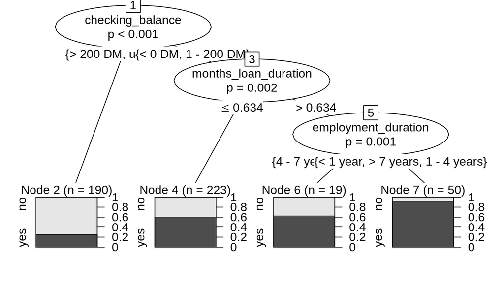

```r
plot(dct2$finalModel)
```

# Testing - Decision Tree

```r
dctpredict2 <- predict(dct2$finalModel, Xtr)
confusionMatrix(dctpredict2,Xtrlabel2$default,positive='no')
```

```
#> Confusion Matrix and Statistics
#>
#>           Reference
#> Prediction no yes
#>        no  82  12
#>        yes 57  47
#>
#>                Accuracy : 0.6515
#>                  95% CI : (0.5807, 0.7177)
#>     No Information Rate : 0.702
#>     P-Value [Acc > NIR] : 0.947
#>
#>                   Kappa : 0.317
#>
#>  Mcnemar's Test P-Value : 1.177e-07
#>
#>             Sensitivity : 0.5899
#>             Specificity : 0.7966
#>          Pos Pred Value : 0.8723
#>          Neg Pred Value : 0.4519
#>              Prevalence : 0.7020
#>          Detection Rate : 0.4141
#>    Detection Prevalence : 0.4747
#>       Balanced Accuracy : 0.6933
#>
#>        'Positive' Class : no
#>
```

Penggunaan downsampling dalam kasus ini menggunakan decision tree membuat accuracy dari data menurun. hipotesa hal ini dikarenakan sample yang semakin sedikit, sehingga membuat decision kurang optimal.

Selanjutnya akan dicoba membuat model random forest dengan menggunakan tidymodels

# Modelling - Random Forest

Melakukan split untuk melakukan 5 fold cross validation dengan pengulangan sebanyak 3 kali

```r
remove(list = ls())

loan <- read.csv("loan.csv")

set.seed(99)
split <- initial_split(loan, prop = 0.8, strata = "default")

rec <- recipe(default ~ ., data =training(split)) %>%
  step_nzv(all_predictors()) %>%
  step_string2factor(all_nominal(),-default) %>%
  step_string2factor(default,levels = c("yes","no")) %>%
  step_center(all_numeric()) %>%
  step_scale(all_numeric()) %>%
  prep(strings_as_factors = FALSE)

X <- juice(rec)
Xtr <- bake(rec,testing(split))

rec2 <- recipe(default ~ ., data =training(split)) %>%
  step_nzv(all_predictors()) %>%
  step_string2factor(all_nominal(),-default) %>%
  step_string2factor(default,levels = c("yes","no")) %>%
  step_downsample(default, ratio = 1/1, seed = 100) %>%
  step_center(all_numeric()) %>%
  step_scale(all_numeric()) %>%
  prep(strings_as_factors = FALSE)

X2 <- juice(rec2)
Xtr2 <- bake(rec,testing(split))
```

```r
set.seed(99)
cv_split <- vfold_cv(X, v = 5, repeats = 3, strata = "default")
```

Selanjutnya dilakukan pembuatan model

```r
model_engine <- rand_forest(mode = "classification")

model_engine <- set_engine(
  object = model_engine,
  engine = "ranger",
  seed = 99,
  num.threads = 4,
  importance = "impurity"
)

model_engine
```

```
#> Random Forest Model Specification (classification)
#>
#> Engine-Specific Arguments:
#>   seed = 99
#>   num.threads = 4
#>   importance = impurity
#>
#> Computational engine: ranger
```

```r
model_grid <- grid_regular(
  range_set(mtry, range = c(2, ncol(X) - 1)),
  range_set(trees, range = c(500, 1000)),
  range_set(min_n, range = c(1, 30)),
  levels = 3
)

model_grid
```

```
#> # A tibble: 27 x 3
#>     mtry trees min_n
#>    <int> <int> <int>
#>  1     2   500     1
#>  2     9   500     1
#>  3    16   500     1
#>  4     2   750     1
#>  5     9   750     1
#>  6    16   750     1
#>  7     2  1000     1
#>  8     9  1000     1
#>  9    16  1000     1
#> 10     2   500    15
#> # … with 17 more rows
```

```r
model_specs <- tibble(spec = merge(model_engine, model_grid)) %>%
  mutate(spec_id = str_pad(row_number(), width = 2, side = "left", pad = "0"))

model_grid <- model_grid %>%
  mutate(spec_id = str_pad(row_number(), width = 2, side = "left", pad = "0"))

crossed <- crossing(cv_split, model_specs)
crossed <- crossed %>%
  mutate(model = map2(spec, splits, ~
    fit_xy(.x, x = select(analysis(.y), -default), y = select(analysis(.y), default))
  ))
```

# Testing- Random Forest

```r
# get hold-out prediction in every folds
cv_result <- crossed %>%
  mutate(prediction = map2(model, splits, ~
    assessment(.y) %>%
      bind_cols(predict(.x, .)) %>%
      bind_cols(predict(.x, ., type = "prob")) %>%
      select(default, starts_with(".pred"))
  ))

# unnest the cv result
cv_result <- cv_result %>%
  select(spec_id, id, id2, prediction) %>%
  unnest(prediction)

# get metrics for every model
grid_result <- cv_result %>%
  group_by(spec_id, id, id2) %>%
  summarise(
    accuracy = accuracy_vec(default, .pred_class)
  ) %>%
  ungroup()

# join with model grid
grid_result <- grid_result %>%
  left_join(model_grid)
```

```r
# plot the result
ggplot(grid_result, aes(x = as.factor(mtry), y = accuracy)) +
  geom_boxplot(aes(fill = as.factor(trees))) +
  coord_flip() +
  facet_wrap(~ min_n, ncol = 3) +
  labs(x = "mtry", y = "Accuracy", fill = "trees") +
  theme_minimal()
```

[figure not shown]

Akan dilakukan pembuatan model menggunakan variabel tersebut dan dilakukan test ke dalam data test

```r
model_spec2 <- rand_forest(
  mode = "classification",
  mtry = 8,
  trees = 750,
  min_n = 15
)

model_spec2 <- set_engine(
  object = model_spec2,
  engine = "ranger",
  seed = 100,
  num.threads = 4,
  importance = "impurity"
)

model <- fit_xy(model_spec2, x = X[,-17], y = X[,17])
```

```r
pred_test <- bake(rec, testing(split)) %>%
  bind_cols(predict(model, .)) %>%
  bind_cols(predict(model, ., type = "prob")) %>%
  select(default, starts_with(".pred"))
```

```r
confusionMatrix(pred_test$.pred_class,Xtr$default,positive='no')
```

```
#> Confusion Matrix and Statistics
#>
#>           Reference
#> Prediction  no yes
#>        no  129  34
#>        yes  10  25
#>
#>                Accuracy : 0.7778
#>                  95% CI : (0.7134, 0.8336)
#>     No Information Rate : 0.702
#>     P-Value [Acc > NIR] : 0.0106276
#>
#>                   Kappa : 00.3984
#>
#>  Mcnemar's Test P-Value : 0.0005256
#>
#>             Sensitivity : 0.9281
#>             Specificity : 0.4237
#>          Pos Pred Value : 0.7914
#>          Neg Pred Value : 0.7143
#>              Prevalence : 0.7020
#>          Detection Rate : 0.6515
#>    Detection Prevalence : 0.8232
#>       Balanced Accuracy : 0.6759
#>
#>        'Positive' Class : no
#>
```

Model Random Forest menghasilkan model dengan accuracy 77%, lebih baik dari kedua model sebelumnya, naive bayes dan decision tree

Kemudian sama seperti kedua model sebelumnya, akan dilakukan pengecekan ketika data dilakukan downsampling

# Random Forest - With Downsampling

```r
set.seed(99)
cv_split2 <- vfold_cv(X2, v = 5, repeats = 3, strata = "default")
```

```r
crossed2 <- crossing(cv_split2, model_specs)

crossed2 <- crossed2 %>%
  mutate(model = map2(spec, splits, ~
    fit_xy(.x, x = select(analysis(.y), -default), y = select(analysis(.y), default))
  ))
```

```r
# get hold-out prediction in every folds
cv_result2 <- crossed2 %>%
  mutate(prediction = map2(model, splits, ~
    assessment(.y) %>%
      bind_cols(predict(.x, .)) %>%
      bind_cols(predict(.x, ., type = "prob")) %>%
      select(default, starts_with(".pred"))
  ))

# unnest the cv result
cv_result2 <- cv_result2 %>%
  select(spec_id, id, id2, prediction) %>%
  unnest(prediction)

# get metrics for every model
grid_result2 <- cv_result2 %>%
  group_by(spec_id, id, id2) %>%
  summarise(
    accuracy = accuracy_vec(default, .pred_class)
  ) %>%
  ungroup()

# join with model grid
grid_result2 <- grid_result2 %>%
  left_join(model_grid)
```

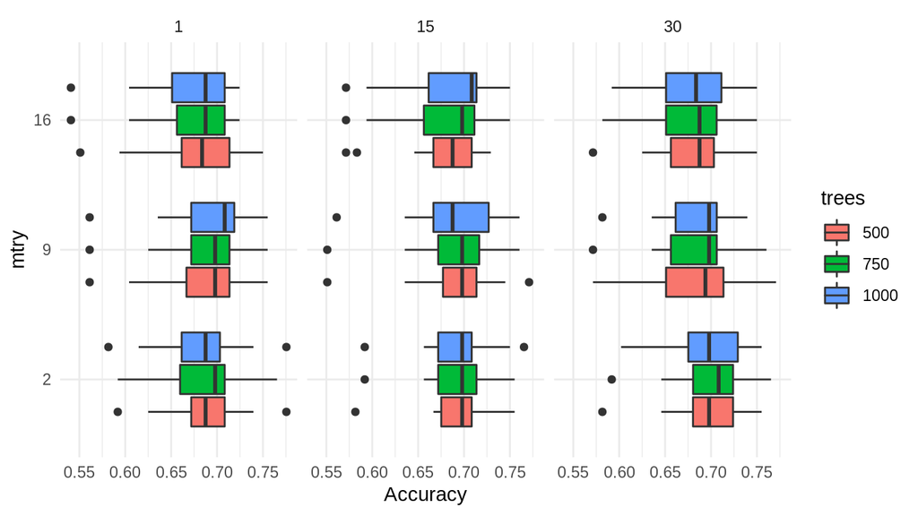

```r
# plot the result
ggplot(grid_result2, aes(x = as.factor(mtry), y = accuracy)) +
  geom_boxplot(aes(fill = as.factor(trees))) +
  coord_flip() +
  facet_wrap(~ min_n, ncol = 3) +
  labs(x = "mtry", y = "Accuracy", fill = "trees") +
  theme_minimal()
```

Akan dilakukan pengetesan terhadap data test dengan menggunakan parameter tersebut

```r
model_spec3 <- rand_forest(
  mode = "classification",
  mtry = 2,
  trees = 1000,
  min_n = 30
)

model_spec3 <- set_engine(
  object = model_spec3,
  engine = "ranger",
  seed = 100,
  num.threads = 4,
  importance = "impurity"
)

model <- fit_xy(model_spec3, x = X[,-17], y = X[,17])
```

```r
pred_test2 <- bake(rec, testing(split)) %>%
  bind_cols(predict(model, .)) %>%
  bind_cols(predict(model, ., type = "prob")) %>%
  select(default, starts_with(".pred"))
```

```r
confusionMatrix(pred_test2$.pred_class,Xtr2$default,positive='no')
```

```
#> Confusion Matrix and Statistics
#>
#>           Reference
#> Prediction  no yes
#>        no  136  46
#>        yes   3  13
#>
#>                Accuracy : 0.7525
#>                  95% CI : (0.6864, 0.811)
#>     No Information Rate : 0.702
#>     P-Value [Acc > NIR] : 0.06811
#>
#>                   Kappa : 0.2515
#>
#>  Mcnemar's Test P-Value : 1.973e-09
#>
#>             Sensitivity : 0.9784
#>             Specificity : 0.2203
#>          Pos Pred Value : 0.7473
#>          Neg Pred Value : 0.8125
#>              Prevalence : 0.7020
#>          Detection Rate : 0.6869
#>    Detection Prevalence : 0.9192
#>       Balanced Accuracy : 0.5994
#>
#>        'Positive' Class : no
#>
```

# Kesimpulan

- Dari ketiga model, random forest menghasilkan model terbaik, dengan angka akurasi = 77%, namun secara komputasi random forest jauh lebih kompleks dibandiing kedua model lain nya.
- Preprosessing downsampling tidak selalu membuat performance model menjadi lebih baik